# index

Kate Gordon

2024-09-10

```r
library("tidytuesdayR")
library("tidyverse")
library("here")
chocolate <- readRDS(here("data", "chocolate.RDS"))
as_tibble(chocolate)
```

```
## # A tibble: 2,530 × 10
##      ref company_manufacturer company_location review_date
##    <dbl> <chr>                <chr>                  <dbl>
##  1  2454 5150                 U.S.A.                  2019
##  2  2458 5150                 U.S.A.                  2019
##  3  2454 5150                 U.S.A.                  2019
##  4  2542 5150                 U.S.A.                  2021
##  5  2546 5150                 U.S.A.                  2021
##  6  2546 5150                 U.S.A.                  2021
##  7  2542 5150                 U.S.A.                  2021
##  8   797 A. Morin             France                  2012
##  9   797 A. Morin             France                  2012
## 10  1011 A. Morin             France                  2013
## # ℹ 2,520 more rows
## # ℹ 6 more variables: country_of_bean_origin <chr>,
## #   specific_bean_origin_or_bar_name <chr>, cocoa_percent <chr>,
## #   ingredients <chr>, most_memorable_characteristics <chr>, rating <dbl>
```

```r
glimpse(chocolate)
```

```
## Rows: 2,530
## Columns: 10
## $ ref                              <dbl> 2454, 2458, 2454, 2542, 2546, 2546, 2…
## $ company_manufacturer             <chr> "5150", "5150", "5150", "5150", "5150…
## $ company_location                 <chr> "U.S.A.", "U.S.A.", "U.S.A.", "U.S.A.…
## $ review_date                      <dbl> 2019, 2019, 2019, 2021, 2021, 2021, 2…
## $ country_of_bean_origin           <chr> "Tanzania", "Dominican Republic", "Ma…
## $ specific_bean_origin_or_bar_name <chr> "Kokoa Kamili, batch 1", "Zorzal, bat…
## $ cocoa_percent                    <chr> "76%", "76%", "76%", "68%", "72%", "8…
## $ ingredients                      <chr> "3- B,S,C", "3- B,S,C", "3- B,S,C", "…
## $ most_memorable_characteristics   <chr> "rich cocoa, fatty, bready", "cocoa, …
## $ rating                           <dbl> 3.25, 3.50, 3.75, 3.00, 3.00, 3.25, 3…
```

**##Part 1: Explore data**  
In this part, use functions from dplyr and ggplot2 to answer the following questions.

**1. Make a histogram of the rating scores to visualize the overall distribution of scores**

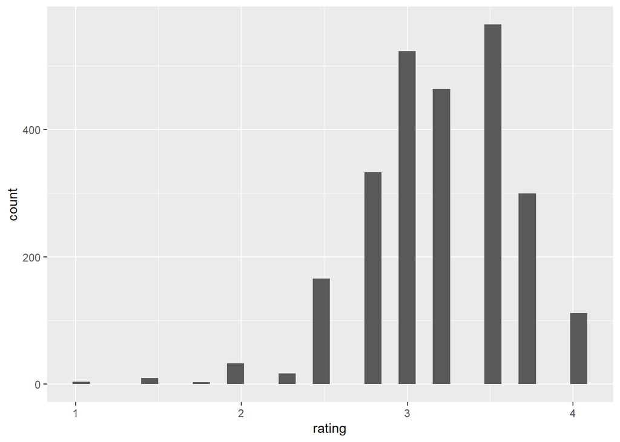

```r
library(ggplot2)
# Create a basic histogram of the rating scores
ggplot(chocolate, aes(x=rating)) + geom_histogram()
```

Change the number of bins from the default to 10, 15, 20, and 25.

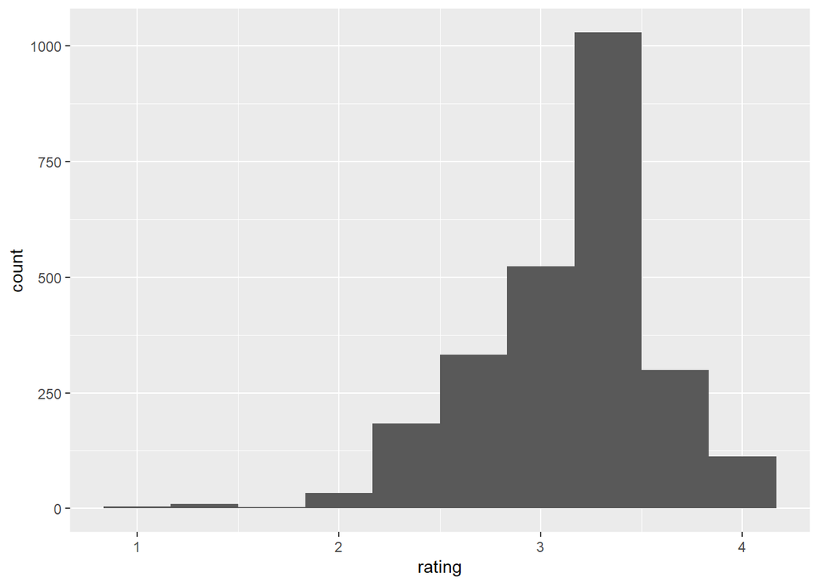

```r
ggplot(chocolate, aes(x=rating)) + geom_histogram(bins = 10)
```

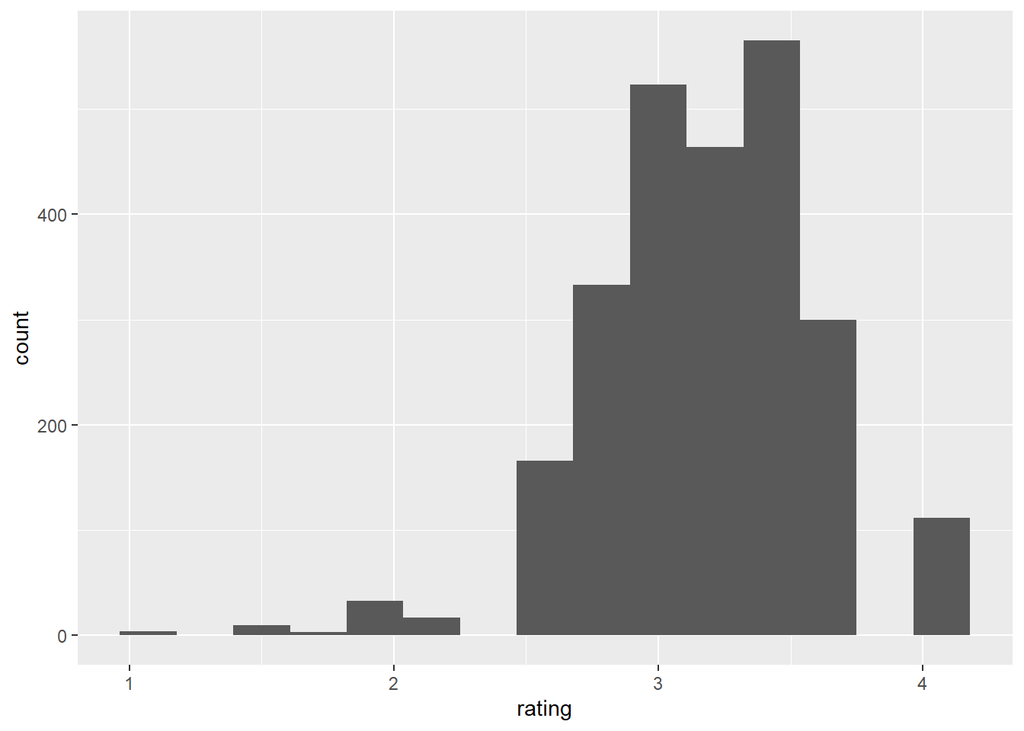

```r
ggplot(chocolate, aes(x=rating)) + geom_histogram(bins = 15)
```

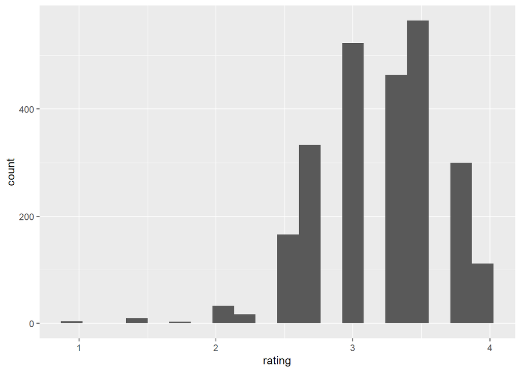

```r
ggplot(chocolate, aes(x=rating)) + geom_histogram(bins = 20)
```

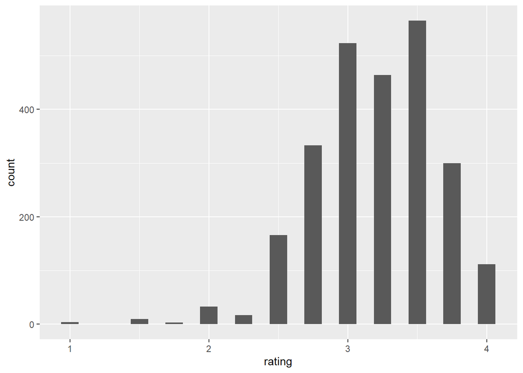

```r
ggplot(chocolate, aes(x=rating)) + geom_histogram(bins = 25)
```

**Pick on the one that you think looks the best.**

I think the one that looks the best is using **15 bins**.

**Explain what the difference is when you change the number of bins and explain why you picked the one you did.** When the number of bins decreased, the ratings were aggregated into larger groups, allowing the shape of the full distribution to be more easily observed. This shows us thaat the distributin is left-skewed. When decreased to 10 bins, we also observe that the y-axis increases from a maximum of 600 counts to over 1000 counts. I chose this histogram with **15 bins** because it allows us to see that there is a left skew to the distribution with enough detail to quickly observe outliers and rating fluctuations.

**2. Consider the countries where the beans originated from. How many reviews come from each country of bean origin?**

```r
#Creating a summary table and visualisation grouping the reviews by country of bean origin.

reviews_by_country_of_bean_origin <-
  chocolate %>%
  group_by(country_of_bean_origin) %>%
  summarise(n_ratings = n())
# Print reviews by country of origin
options(dplyr.print_min = Inf)
print((reviews_by_country_of_bean_origin))
```

```
## # A tibble: 62 × 2
##    country_of_bean_origin n_ratings
##    <chr>                      <int>
##  1 Australia                      3
##  2 Belize                        76
##  3 Blend                        156
##  4 Bolivia                       80
##  5 Brazil                        78
##  6 Burma                          1
##  7 Cameroon                       3
##  8 China                          1
##  9 Colombia                      79
## 10 Congo                         11
## 11 Costa Rica                    43
## 12 Cuba                          12
```

[output cut: 50 more lines]

**3. What is average rating scores from reviews of chocolate bars that have Ecuador as country_of_bean_origin in this dataset?**

For this same set of reviews, also calculate (1) the total number of reviews and (2) the standard deviation of the rating scores.

Your answer should be a new data frame with these three summary statistics in three columns.

Label the name of these columns mean, sd, and total.**

```r
average_rating_scores <-
  chocolate %>%
  group_by(country_of_bean_origin) %>%
  summarise(mean = mean(rating), sd = sd(rating), total= n(), )

average_rating_scores
```

```
## # A tibble: 62 × 4
##    country_of_bean_origin  mean     sd total
##    <chr>                  <dbl>  <dbl> <int>
##  1 Australia               3.25  0.5       3
##  2 Belize                  3.23  0.325    76
##  3 Blend                   3.04  0.638   156
##  4 Bolivia                 3.18  0.436    80
##  5 Brazil                  3.26  0.417    78
##  6 Burma                   3    NA         1
##  7 Cameroon                3.08  0.144     3
##  8 China                   3.5  NA         1
##  9 Colombia                3.20  0.423    79
## 10 Congo                   3.32  0.318    11
## 11 Costa Rica              3.15  0.409    43
## 12 Cuba                    3.29  0.411    12
```

[output cut: 50 more lines]

**Answer: The average rating scores from reviews of chocolate bars that have Ecuador as country_of_bean_origin in this dataset is 3.164384**

```r
Ecuador <- filter(average_rating_scores, country_of_bean_origin == "Ecuador")
print((Ecuador))
```

```
## # A tibble: 1 × 4
##   country_of_bean_origin  mean    sd total
##   <chr>                  <dbl> <dbl> <int>
## 1 Ecuador                 3.16 0.512   219
```

**4. Which company location makes the best chocolate (or has the highest ratings on average) with beans from Ecuador?**

```r
highest_ecuadorian_rated_manufacturer <-
  chocolate %>%
  group_by(country_of_bean_origin) %>%
  filter(country_of_bean_origin == "Ecuador") %>%
  group_by(company_location) %>%
  summarise(mean = mean(rating)) %>%
  arrange(desc(mean))
  print(highest_ecuadorian_rated_manufacturer)
```

```
## # A tibble: 25 × 2
##    company_location  mean
##    <chr>            <dbl>
##  1 Australia         3.81
##  2 Switzerland       3.75
##  3 New Zealand       3.62
##  4 Hungary           3.5
##  5 Israel            3.5
##  6 Netherlands       3.5
##  7 Singapore         3.5
##  8 South Korea       3.33
##  9 Canada            3.28
## 10 U.S.A.            3.26
## 11 Argentina         3.25
## 12 Nicaragua         3.25
## 13 Poland            3.25
## 14 Russia            3.25
## 15 France            3.19
## 16 Italy             3.19
## 17 U.K.              3.08
## 18 Belgium           3.05
## 19 Ecuador           3.00
## 20 Spain             2.94
## 21 Austria           2.88
## 22 Denmark           2.5
## 23 Scotland          2.5
## 24 South Africa      2.5
## 25 Germany           2.44
```

**Answer: Australia with a mean score of 3.81**

**5. Calculate the average rating across all country of origins for beans. Which top 3 countries (for bean origin) have the highest ratings on average?**

```r
highest_average_rating_scores <-
  average_rating_scores %>%
  reframe(country_of_bean_origin, mean) %>%
  arrange(desc(mean))
as_tibble(highest_average_rating_scores) %>%
    print(n = 3, width = Inf)
```

```
## # A tibble: 62 × 2
##   country_of_bean_origin  mean
##   <chr>                  <dbl>
## 1 Tobago                  3.62
## 2 China                   3.5
## 3 Sao Tome & Principe     3.5
## # ℹ 59 more rows
```

**Answer: The top 3 countries (for bean origin) that have the highest ratings on average are: Tobago, China, and Sao Tome & Princip.**

**6. Following up on the previous problem, now remove any countries of bean origins that have less than 10 chocolate bar reviews. Now, which top 3 countries have the highest ratings on average?**

```r
revised_highest_average_rating_scores <-
  average_rating_scores %>%
  reframe(country_of_bean_origin, mean, total) %>%
  arrange(desc(mean)) %>%
  filter(total >= 10)
as_tibble(revised_highest_average_rating_scores) %>%
    print(n = 3, width = Inf)
```

```
## # A tibble: 35 × 3
##   country_of_bean_origin  mean total
##   <chr>                  <dbl> <int>
## 1 Solomon Islands         3.45    10
## 2 Congo                   3.32    11
## 3 Cuba                    3.29    12
## # ℹ 32 more rows
```

**Answer: The top 3 countries of bean origins that have the highest ratings on average with 10 or more chocolate bar reviews are: Solomon Islands, Congo and Cuba**

**7. For this last part, let’s explore the relationship between percent chocolate and ratings. Use the functions in dplyr, tidyr, and lubridate to perform the following steps to the chocolate dataset:**

Identify the countries of bean origin with at least 50 reviews. Remove reviews from countries are not in this list.

```r
Countries_with_50_plus_reviews <- chocolate %>%
  group_by(country_of_bean_origin) %>%
  reframe(country_of_bean_origin, rating, total= n(), cocoa_percent) %>%
   filter(total >= 50) %>%
  arrange(desc(total))
as_tibble(Countries_with_50_plus_reviews) %>%
    print(n = 3, width = Inf)
```

```
## # A tibble: 2,007 × 4
##   country_of_bean_origin rating total cocoa_percent
##   <chr>                   <dbl> <int> <chr>
## 1 Venezuela                3      253 72%
## 2 Venezuela                4      253 70%
## 3 Venezuela                2.75   253 70%
## # ℹ 2,004 more rows
```

Using the variable describing the chocolate percentage for each review, create a new column that groups chocolate percentages into one of four groups: (i) <60%, (ii) >=60 to <70%, (iii) >=70 to <90%, and (iii) >=90% (Hint check out the substr() function in base R and the case_when() function from dplyr).

```r
#Create a new column that groups chocolate percentages into one of four groups:
#(i) <60%, (ii) >=60 to <70%, (iii) >=70 to <90%, and (iii) >=90%
Categorized_Countries_with_50_plus_reviews <- Countries_with_50_plus_reviews %>%
mutate(cocoa_cat = case_when(cocoa_percent < "60" ~ "i",
                             cocoa_percent >= "60" & cocoa_percent < "70" ~ "ii",
            cocoa_percent >= "70" & cocoa_percent < "90" ~ "iii",
            cocoa_percent >= "90" ~ "iv"))
```

Using the new column described in #2, re-order the factor levels (if needed) to be starting with the smallest percentage group and increasing to the largest percentage group (Hint check out the fct_relevel() function from forcats).

```r
Categorized_Countries_with_50_plus_reviews <- Categorized_Countries_with_50_plus_reviews %>%
  mutate(cocoa_cat=factor(cocoa_cat)) %>%
  mutate(cocoa_cat=fct_relevel(cocoa_cat,c("i","ii","iii","iv"))) %>%
 arrange(cocoa_cat)
```

For each country, make a set of four side-by-side boxplots plotting the groups on the x-axis and the ratings on the y-axis. These plots should be faceted by country.

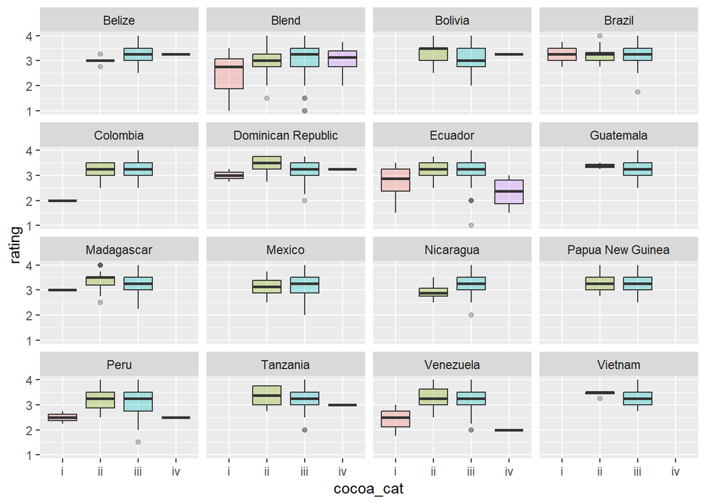

```r
ggp <- ggplot(Categorized_Countries_with_50_plus_reviews, aes(x = cocoa_cat, y = rating, fill = cocoa_cat)) +
  geom_boxplot(alpha=0.3) +
theme(legend.position="none") +
  facet_wrap(~country_of_bean_origin, scales = "fixed")
ggp
```

**On average, which category of chocolate percentage is most highly rated? Do these countries mostly agree or are there disagreements?**

```r
rating  <- Categorized_Countries_with_50_plus_reviews$rating
cocoa_cat <- Categorized_Countries_with_50_plus_reviews$cocoa_cat
mean_rating <- tapply(rating, cocoa_cat, mean)
mean_rating
```

```
##        i       ii      iii       iv
## 2.664634 3.246296 3.218787 2.750000
```

**Answer: On average category II is most highly rated. However there are disagreements in countries such as Nicaragua, Mexico and Brazil where category III rates higher.**

**Part 2: Join two datasets together** Join two datasets together chocolate and gapminder unfiltered

**Tasks** Use this dataset it to create a new column called continent in our chocolate dataset that contains the continent name for each review where the country of bean origin is. Only keep reviews that have reviews from countries of bean origin with at least 10 reviews. Also, remove the country of bean origin named “Blend”. Make a set of violin plots with ratings on the y-axis and continents on the x-axis.

#installed install.packages(“gapminder”)

```r
library(gapminder)
# countries with info in gapminder::gapminder_unfiltered
gapminder <-gapminder::gapminder_unfiltered
```

#group by country of bean origin, add total number of reviews per country, remove countries with <10 reviews and the country of origin labelled Blend

```r
data_1 <- gapminder%>%distinct(country, .keep_all=TRUE) #delete duplicate countries
gapminder1 <- data_1%>%select(1,2) #select only continent and country
gapminder2 <- rename(gapminder1, country_of_bean_origin=country)

data_2 <- left_join(x=chocolate, y=gapminder2, by="country_of_bean_origin")
data_3 <- arrange(data_2,by=country_of_bean_origin)
```

2. Keep only countries that have at least 10 reviews

```r
count <- data_3%>%count(country_of_bean_origin)
count2 <- filter(count, n >= 10)

Countries_with_at_least_10 <- inner_join(data_3, count2, by="country_of_bean_origin")
glimpse(Countries_with_at_least_10)
```

```
## Rows: 2,448
## Columns: 12
## $ ref                              <dbl> 1494, 2586, 1598, 2290, 1768, 1768, 1…
## $ company_manufacturer             <chr> "Ambrosia", "Animas", "Arete", "Banks…
## $ company_location                 <chr> "Canada", "U.S.A.", "U.S.A.", "U.S.A.…
## $ review_date                      <dbl> 2015, 2021, 2015, 2019, 2016, 2016, 2…
## $ country_of_bean_origin           <chr> "Belize", "Belize", "Belize", "Belize…
## $ specific_bean_origin_or_bar_name <chr> "Belize", "Maya Mountain, batch 39", …
## $ cocoa_percent                    <chr> "64%", "75%", "70%", "72%", "83%", "7…
## $ ingredients                      <chr> "4- B,S,C,L", "2- B,S", "2- B,S", "3-…
## $ most_memorable_characteristics   <chr> "roasty, brownie, nutty", "burnt toas…
## $ rating                           <dbl> 3.00, 3.00, 3.75, 2.50, 2.75, 3.00, 3…
## $ continent                        <fct> Americas, Americas, Americas, America…
## $ n                                <int> 76, 76, 76, 76, 76, 76, 76, 76, 76, 7…
```

3. Remove the country of origin named BLEND

```r
data_4 <- subset(Countries_with_at_least_10, country_of_bean_origin!="Blend")
glimpse(data_4)
```

```
## Rows: 2,292
## Columns: 12
## $ ref                              <dbl> 1494, 2586, 1598, 2290, 1768, 1768, 1…
## $ company_manufacturer             <chr> "Ambrosia", "Animas", "Arete", "Banks…
## $ company_location                 <chr> "Canada", "U.S.A.", "U.S.A.", "U.S.A.…
## $ review_date                      <dbl> 2015, 2021, 2015, 2019, 2016, 2016, 2…
## $ country_of_bean_origin           <chr> "Belize", "Belize", "Belize", "Belize…
## $ specific_bean_origin_or_bar_name <chr> "Belize", "Maya Mountain, batch 39", …
## $ cocoa_percent                    <chr> "64%", "75%", "70%", "72%", "83%", "7…
## $ ingredients                      <chr> "4- B,S,C,L", "2- B,S", "2- B,S", "3-…
## $ most_memorable_characteristics   <chr> "roasty, brownie, nutty", "burnt toas…
## $ rating                           <dbl> 3.00, 3.00, 3.75, 2.50, 2.75, 3.00, 3…
## $ continent                        <fct> Americas, Americas, Americas, America…
## $ n                                <int> 76, 76, 76, 76, 76, 76, 76, 76, 76, 7…
```

Check for and correct NA continent values

```r
data_4$continent[data_4$country_of_bean_origin == "Trinidad"] <- "Americas"
data_4$continent[data_4$country_of_bean_origin == "Congo"] <- "Africa"
data_4$continent[data_4$country_of_bean_origin == "Sao Tome"] <- "Africa"
data_4$continent[data_4$country_of_bean_origin == "St. Lucia"] <- "Americas"
data_4$continent[data_4$country_of_bean_origin == "U.S.A."] <- "Americas"
```

**Make a set of violin plots with ratings on the y-axis and continents on the x-axis.**

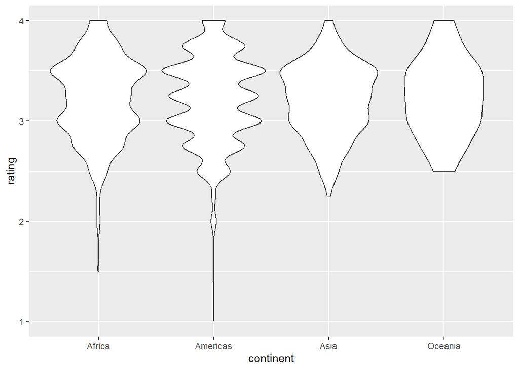

```r
library(ggplot2)
# Violin plot
Violin_Plot <- ggplot(data_4, aes(x=continent, y=rating)) +
  geom_violin()
Violin_Plot
```

**Part 3: Convert wide data into long data** Tasks We are going to create a set of features for us to plot over time. Use the functions in dplyr and tidyr to perform the following steps to the chocolate dataset:

Create a new set of columns titled beans, sugar, cocoa_butter, vanilla, letchin, and salt that contain a 1 or 0 representing whether or not that review for the chocolate bar contained that ingredient (1) or not (0). See this public gist for how to differentiate S vs S* vs Sa using str_detect() from the stringr package.

```r
chocolate <- chocolate %>%
        mutate(
                sugar = case_when(
                        str_detect(ingredients, regex("S,|S$", ignore_case = TRUE)) ~ 1,
                        TRUE ~ 0))

chocolate <- chocolate %>%
        mutate(
                bean = case_when(
                        str_detect(ingredients, regex("B", ignore_case = TRUE)) ~ 1,
                        TRUE ~ 0))

chocolate <- chocolate %>%
        mutate(
                cocoa_butter = case_when(
                        str_detect(ingredients, regex("C", ignore_case = TRUE)) ~ 1,
                        TRUE ~ 0))

chocolate <- chocolate %>%
        mutate(
                vanilla = case_when(
                        str_detect(ingredients, regex("V", ignore_case = TRUE)) ~ 1,
                        TRUE ~ 0))

chocolate <- chocolate %>%
        mutate(
                letchin = case_when(
                        str_detect(ingredients, regex("L", ignore_case = TRUE)) ~ 1,
                        TRUE ~ 0))

chocolate <- chocolate %>%
        mutate(
                salt = case_when(
                        str_detect(ingredients, regex("Sa", ignore_case = TRUE)) ~ 1,
                        TRUE ~ 0))
```

Create a new set of columns titled char_cocoa, char_sweet, char_nutty, char_creamy, char_roasty, char_earthy that contain a 1 or 0 representing whether or not that the most memorable characteristic for the chocolate bar had that word (1) or not (0). For example, if the word “sweet” appears in the most_memorable_characteristics, then record a 1, otherwise a 0 for that review in the char_sweet column (Hint: check out str_detect() from the stringr package).

```r
chocolate <- chocolate %>%
        mutate(
                char_cocoa = case_when(
                        str_detect(most_memorable_characteristics, regex("cocoa", ignore_case = TRUE)) ~ 1,
                        TRUE ~ 0))

chocolate <- chocolate %>%
        mutate(
                char_sweet = case_when(
                        str_detect(most_memorable_characteristics, regex("sweet", ignore_case = TRUE)) ~ 1,
                        TRUE ~ 0))

chocolate <- chocolate %>%
        mutate(
                char_nutty = case_when(
                        str_detect(most_memorable_characteristics, regex("nutty", ignore_case = TRUE)) ~ 1,
                        TRUE ~ 0))

chocolate <- chocolate %>%
        mutate(
                char_creamy = case_when(
                        str_detect(most_memorable_characteristics, regex("creamy", ignore_case = TRUE)) ~ 1,
                        TRUE ~ 0))

chocolate <- chocolate %>%
        mutate(
                char_roasty = case_when(
                        str_detect(most_memorable_characteristics, regex("roasty", ignore_case = TRUE)) ~ 1,
                        TRUE ~ 0))

chocolate <- chocolate %>%
        mutate(
                char_earthy = case_when(
                        str_detect(most_memorable_characteristics, regex("earthy", ignore_case = TRUE)) ~ 1,
                        TRUE ~ 0))
```

For each year (i.e. review_date), calculate the mean value in each new column you created across all reviews for that year. (Hint: If all has gone well thus far, you should have a dataset with 16 rows and 13 columns).

```r
#Create subset of chocolate data set to just review date and features (flavor, taste)
#and name it "new chocolate"
new_chocolate <- chocolate%>%
select(  review_date, bean, sugar, cocoa_butter, vanilla, letchin, salt, char_cocoa, char_sweet, char_creamy, char_earthy, char_roasty, char_nutty)
 glimpse(new_chocolate)
```

```
## Rows: 2,530
## Columns: 13
## $ review_date  <dbl> 2019, 2019, 2019, 2021, 2021, 2021, 2021, 2012, 2012, 201…
## $ bean         <dbl> 1, 1, 1, 1, 1, 1, 1, 1, 1, 1, 1, 1, 1, 1, 1, 1, 1, 1, 1, …
## $ sugar        <dbl> 1, 1, 1, 1, 1, 1, 1, 1, 1, 1, 1, 1, 1, 1, 1, 1, 1, 1, 1, …
## $ cocoa_butter <dbl> 1, 1, 1, 1, 1, 1, 1, 1, 1, 1, 1, 1, 1, 1, 1, 1, 1, 1, 1, …
## $ vanilla      <dbl> 0, 0, 0, 0, 0, 0, 0, 0, 0, 0, 0, 0, 0, 0, 0, 0, 0, 0, 0, …
## $ letchin      <dbl> 0, 0, 0, 0, 0, 0, 0, 1, 1, 1, 1, 1, 1, 1, 1, 1, 1, 1, 1, …
## $ salt         <dbl> 0, 0, 0, 0, 0, 0, 0, 0, 0, 0, 0, 0, 0, 0, 0, 0, 0, 0, 0, …
## $ char_cocoa   <dbl> 1, 1, 1, 0, 0, 1, 0, 0, 0, 0, 0, 0, 0, 0, 0, 1, 1, 1, 0, …
## $ char_sweet   <dbl> 0, 0, 0, 0, 0, 0, 0, 0, 0, 0, 0, 0, 0, 0, 0, 0, 0, 0, 0, …
## $ char_creamy  <dbl> 0, 0, 0, 0, 0, 0, 0, 0, 0, 0, 0, 0, 0, 0, 0, 0, 0, 0, 0, …
## $ char_earthy  <dbl> 0, 0, 0, 0, 1, 0, 0, 0, 0, 1, 0, 0, 0, 0, 0, 0, 0, 0, 0, …
## $ char_roasty  <dbl> 0, 0, 0, 0, 0, 0, 0, 0, 1, 0, 0, 0, 0, 0, 0, 0, 0, 0, 0, …
## $ char_nutty   <dbl> 0, 0, 0, 0, 1, 0, 0, 1, 0, 1, 0, 0, 0, 0, 0, 1, 0, 1, 0, …
```

```r
#installed install.packages("plyr")
library(plyr)
library(dplyr)
new_chocolate_2 <- ddply(new_chocolate, .(review_date), summarize,  bean=mean(bean), sugar=mean(sugar), cocoa_butter=mean(cocoa_butter), vanilla=mean(vanilla), letchin=mean(letchin), salt=mean(salt), char_cocoa=mean(char_cocoa), char_sweet=mean(char_sweet), char_creamy=mean(char_creamy), char_earthy=mean(char_earthy), char_roasty=mean(char_roasty), char_nutty=mean(char_nutty))
```

```r
new_chocolate_2 <- new_chocolate_2 %>%
 pivot_longer(cols = 'bean':'char_nutty',
               names_to = "feature",
               values_to = "mean_score")  %>%
  arrange(review_date)
```

**Part 4: Data visualization**

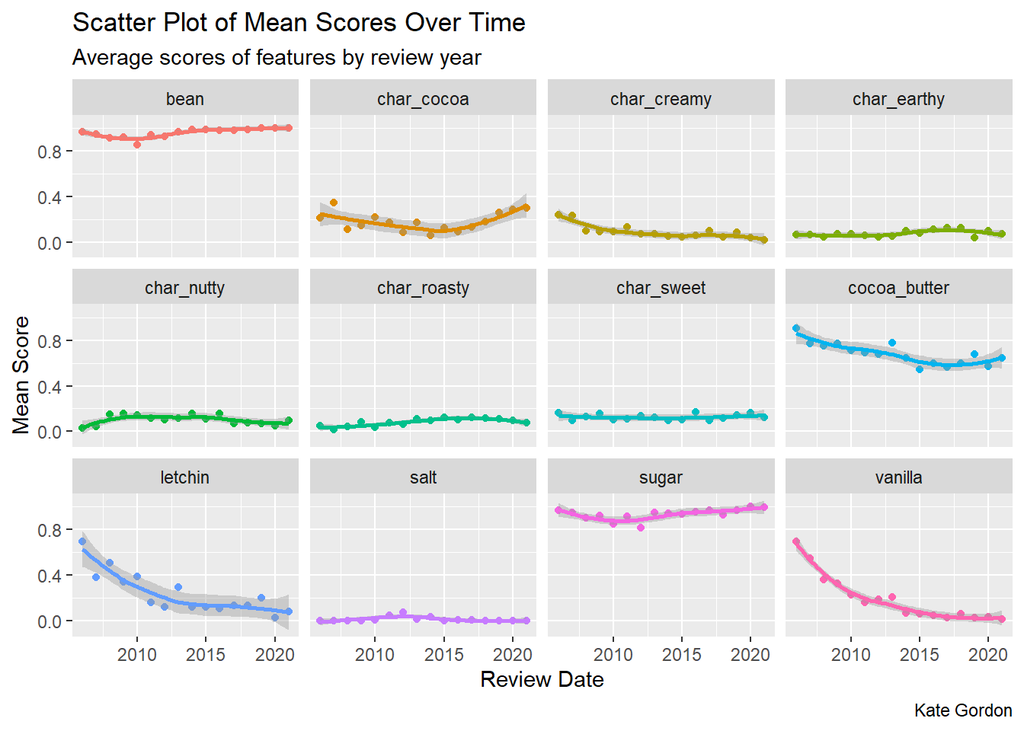

```r
library(ggplot2)
ggplot(new_chocolate_2, aes(x = review_date, y = mean_score, col = new_chocolate_2$feature)) +
  geom_point() +
  geom_smooth() +
theme(legend.position="none") +
  facet_wrap(~feature, scales = "fixed") +
    labs(
    title = "Scatter Plot of Mean Scores Over Time",
    subtitle = "Average scores of features by review year",
    caption = "Kate Gordon",
     x = "Review Date",
    y = "Mean Score",

  )
```

**Part 5: : Make the worst plot you can!**

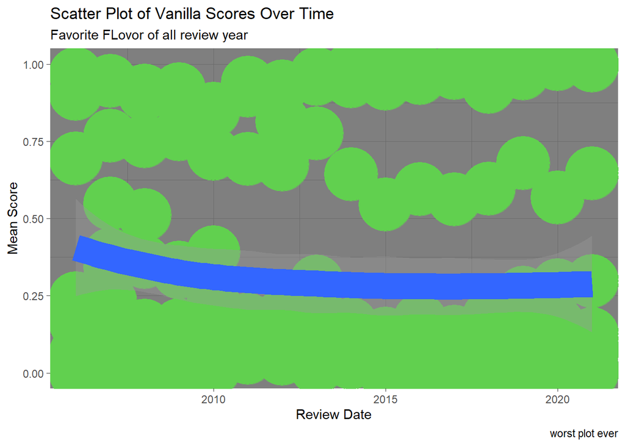

```r
library(ggplot2)
ggplot(new_chocolate_2, aes(x = review_date, y = mean_score, col = new_chocolate_2$vanilla)) +
  geom_point(size=20, color=27) +
  geom_smooth(size = 10) +
theme_dark () +
    labs(
    title = "Scatter Plot of Vanilla Scores Over Time",
    subtitle = "Favorite FLovor of all review year",
    caption = "worst plot ever",
    x = "Review Date",
    y = "Mean Score"
       )
```

- I set the caption as “worst plot ever”. When making awesome plots, you need to make sure your titles match the data.
- I set my theme to “dark”. When making awesome plots, you need to make sure your themes enhance the reader’s ability to see your data points.
- I mislabeled my Title. When making awesome plots, you need to make sure your title accurately represents the your in the plot.
- I mislabeled my Subtitle. When making awesome plots, you need to make sure your subtitle also accurately represents the conclusion made by the data in the plot.
- I set my point size to 20. When making awesome plots, you need to make sure your the point in the plot do not overlap.
- I set my point color to 27, a lime green. When making awesome plots, you need to make sure your color scheme is not distracting to the reader.
- I set my smooth line to 10. When making awesome plots, you need to make sure your line is meaningful in the plot and does not look like an added shape or other data points.

**Part 6: Make my plot a better plot!** Take a sad looking plot and make it better!

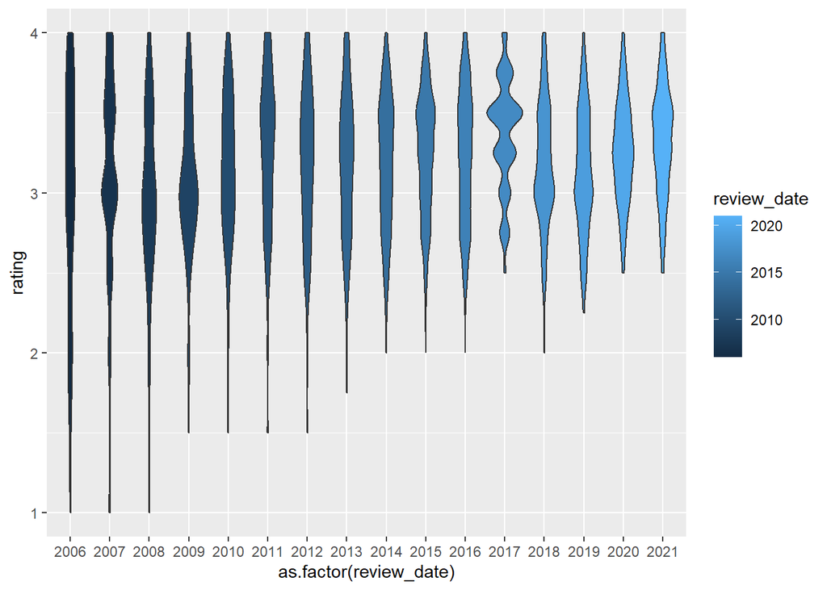

```r
chocolate %>%
    ggplot(aes(
        x = as.factor(review_date),
        y = rating,
        fill = review_date
    )) +
    geom_violin()
```

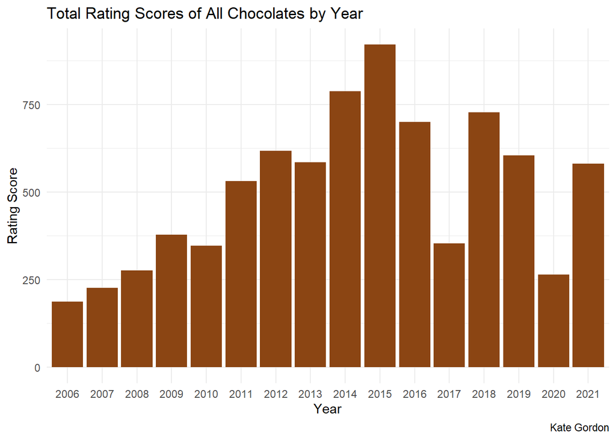

```r
chocolate %>%
    ggplot(aes(
        x = as.factor(review_date),
        y = rating,
        fill = review_date
    )) +
  theme_minimal() +
  guides(fill = FALSE) +
    geom_bar(stat = "identity", fill="chocolate4") +
  labs(
    title = "Total Rating Scores of All Chocolates by Year",
        caption = "Kate Gordon",
    x = "Year",
    y = "Rating Score"
       )
```